# Assignment 1

**Author**: Supreeth Suresh **Date**: 2/12/2025

## Problem 1

In Dynamic Programming, the value Iteration algorithm iteratively applies Bellman backup equation to evaluate the value function, e.g., for state-value function: $$ V_k(s) = \max{a \in A}\left(r + \gamma \sum_{s' \in S} P(s'|s,a) V_{k-1}(s') \right) $$

Write the bellman backup equation for action-value function (Q-function)

Bellman backup equation for action value in dynamic programming is given by The question assumes a deterministic reward. Considering that

$$ Q_k(s, a) = r + \gamma \sum_{s' \in S} P(s'|s,a) \max_{a'} Q_{k-1}(s', a') $$

Where,

```
    k is the iteration number

    r is the reward (deterministic reward)

    Q is the Q value for each state s and action a pair

    s is the state

    a is the action

    s' is the next state

    a' is the next action

    P(s'|s,a) is the probability of next state s' given current state,action pair
```

[figure not shown]

## Problem 2

Consider the following grid environment of a maze navigation problem. Starting from lower-left corner (i.e., position [1, 1]), an agent can move up, down, left, or right. Actions and state transitions are deterministic and always succeed. The objective is to reach the goal position at the upper-right corner (i.e., position [20, 20]). When the agent reaches the goal, it earns a reward 100. Attempting to move in the direction of the boundaries results in termination of the maze navigation, and the agent gets a reward -10. Assume the discount factor 𝛾=0.99, and the learning rate 𝛼=0.01.

[figure not shown]

a. If the objective of the maze navigation is to find the shortest path, design an appropriate immediate reward 𝑟 for every step it takes (except for reaching the goal and hitting the boundaries).

Define rewards for each {state,action} pair  
Given,  
**Reaching the goal:** 100  
**Hitting the boundary:** -10

For each step the agent takes  
-1 a negetive reward (or a penalty) for each step the agent takes to encourage the shortest path.

b. Implement a value iteration algorithm with TD learning for the maze navigation problem. Write down the TD prediction equation that will be used in the algorithm. The skeleton code is given in a MATLAB script, see the file “Maze_TD0_hw1.m”. Complete the code and show the learned state value table and the learning curves over episodes (e.g., the total return earned and steps taken of each episode).

$$ V(s) = V(s) + \alpha [R' + \gamma V(s') - V(s)] $$

Or $$ Td_{error} = R' + \gamma V(s') - V(s) $$ $$ V(s) = V(s) + \alpha * Td_{error} $$

Where,

$V(s)$ Estimated value for state s  
R' is the reward obtained for moving from s to s' using an action defined in the policy  
$\alpha$ Learning rate  
$\gamma$ Discount factor  
$V(s')$ Estimated value for transistioned state s'  
$r$ reward for going to the next state

**Code is written in a elaborate manner to understand the topic. This code can be written in a more efficient way for compute performance**

```
Figure(640x480)
Figure(640x480)
Figure(640x480)

2025-02-23 00:25:17,603 - INFO - Episode number: 0, Total reward: -39
2025-02-23 00:25:18,563 - INFO - Episode number: 1000, Total reward: 51
2025-02-23 00:25:19,537 - INFO - Episode number: 2000, Total reward: 63
2025-02-23 00:25:20,490 - INFO - Episode number: 3000, Total reward: -67
2025-02-23 00:25:21,433 - INFO - Episode number: 4000, Total reward: 61
2025-02-23 00:25:22,386 - INFO - Episode number: 5000, Total reward: 63
2025-02-23 00:25:23,343 - INFO - Episode number: 6000, Total reward: 63
2025-02-23 00:25:24,303 - INFO - Episode number: 7000, Total reward: -49
2025-02-23 00:25:25,269 - INFO - Episode number: 8000, Total reward: 27
2025-02-23 00:25:26,224 - INFO - Episode number: 9000, Total reward: 59
```

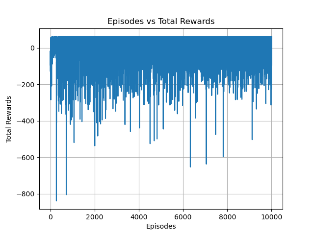

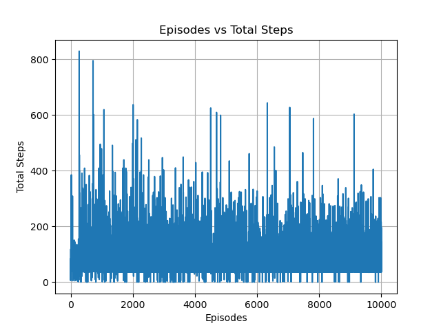

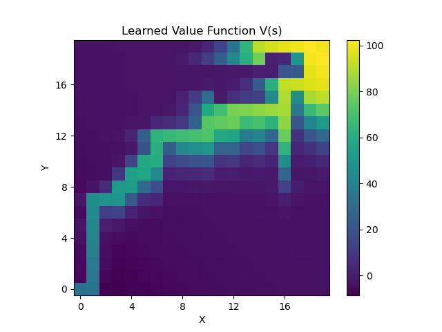

```python
%matplotlib inline
import subprocess
from IPython.display import display, Image

# Run the TD_value_Learning.py script
result = subprocess.run(['python', 'TD_value_Learning.py','--plot'], capture_output=True, text=True)

# Print the output of the script
print(result.stdout)
print(result.stderr)
display(Image(filename='images/episode_totalrewards_plot_TD_valuelearn.png'))
display(Image(filename='images/episode_steps_plot_TD_valuelearn.png'))
display(Image(filename='images/grid_plot_TD_valuelearn.png'))
```

c. Implement a Q-learning algorithm for the maze navigation problem. Write down the TD prediction equation that will be used in the algorithm. The skeleton code is given in a MATLAB script, see the file “Maze_Q_hw1.m”. Complete the code and show the learned Q-table (you may only show the maximum Q) and learning curves over episodes (e.g., the total return earned and steps taken of each episode).

$$ Q(s,a) = Q(s,a) + \alpha [R' + \gamma * max_{a'}(Q(s',a')) - Q(s,a)] $$

Where,

$Q(s,a)$ Estimated Q value for state s with action a  
$\alpha$ Learning rate  
$\gamma$ Discount factor  
$Q(s',a')$ Estimated Q value for transistioned state s' using action a'  
R' is the reward obtained for moving from s to s' using an action a'  
$max_{a'}(Q(s',a'))$ Estimated Q value using greedy action

```
Figure(640x480)
Figure(640x480)
Figure(640x480)

2025-02-23 00:25:27,800 - INFO - Episode number: 0, Total reward: -29
2025-02-23 00:25:28,989 - INFO - Episode number: 1000, Total reward: -57
2025-02-23 00:25:30,077 - INFO - Episode number: 2000, Total reward: -113
2025-02-23 00:25:31,021 - INFO - Episode number: 3000, Total reward: -285
2025-02-23 00:25:31,839 - INFO - Episode number: 4000, Total reward: -26
2025-02-23 00:25:32,551 - INFO - Episode number: 5000, Total reward: -23
2025-02-23 00:25:33,176 - INFO - Episode number: 6000, Total reward: 31
2025-02-23 00:25:33,721 - INFO - Episode number: 7000, Total reward: 49
2025-02-23 00:25:34,194 - INFO - Episode number: 8000, Total reward: 41
2025-02-23 00:25:34,611 - INFO - Episode number: 9000, Total reward: -21
2025-02-23 00:25:34,977 - INFO - Episode number: 10000, Total reward: -22
2025-02-23 00:25:35,297 - INFO - Episode number: 11000, Total reward: 61
2025-02-23 00:25:35,586 - INFO - Episode number: 12000, Total reward: 61
2025-02-23 00:25:35,860 - INFO - Episode number: 13000, Total reward: -13
2025-02-23 00:25:36,136 - INFO - Episode number: 14000, Total reward: 63
```

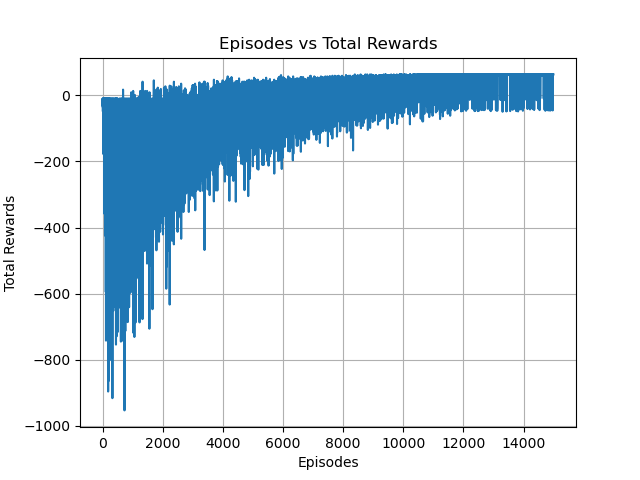

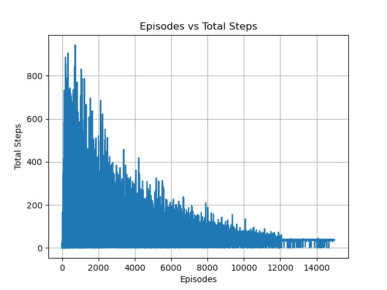

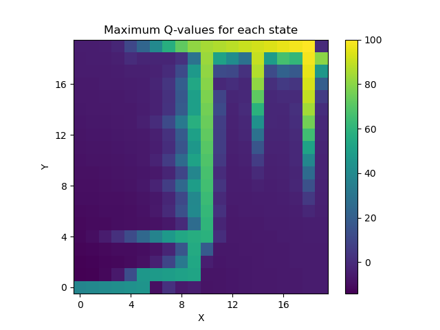

```python
%matplotlib inline
import subprocess
from IPython.display import display, Image

# Run the QLearningn.py script
result = subprocess.run(['python', 'QLearningn.py', '--plot'], capture_output=True, text=True)

# Print the output of the script
print(result.stdout)
print(result.stderr)
display(Image(filename='images/episode_totalrewards_plot_Qlearn.png'))
display(Image(filename='images/episode_steps_plot_Qlearn.png'))
display(Image(filename='images/grid_plot_Qlearn.png'))
#!python QLearningn.py
```

d. Compare and comment on the performance of these two methods that you observe.

## Comparision between using TD(0) vs Q-learning

1. Looking at the Total Rewards in episodes  
   Using V(s): The total rewards varies a lot over the episodes. This learning method is quick to find the positive rewards here but there are multiple large dips (high variance) in the graph even at later episodes indicating a bit of instability in learning. So it hard to say when there is convergence without a clear trend.  
   Using Q(s,a): On the other hand, Q-learning has a reward curve which smoothly increases over the episodes. This method find the positive rewards comparitively slower to TD(0) state value method but it starts from a low value and gradually improves with episodes and shows a clear convergence. The clear convergence shows a more stable learning.
2. Looking at the Total steps per episodes  
   Using V(s): Similar to total rewards graph, the total steps per episodes graph shows the number of steps per episode remains inconsistent. There is no clear decreasing trend in the grpah. This shows a high variance in number of steps.  
   Using Q(s,a): Initially the agent takes a very large number of steps exploring the env with various state and action pair. After a certain episodes, the number of steps decreases and stabilizes at a lower value. This shows a good learning curve.
3. Looking the max V(s) vs max Q(s,a)  
   Using V(s): This method shows a distinction in max V(s) values with less number of episodes.  
   Using Q(s,a): Compared to the other method, Q-learning takes more episode to stabilize the values of Q. But the gradient is more distinct once there is a stabilization. This again asserts the point that Q-learning is more stable.
4. Policy: Finding optimal policy using Q is easier and more accurate. Q directly tells us about both state and action which leads to maximize rewards. On the other hand, when using V(s) we need to check all possible actions and then get the policy.
5. Changing the parameters Learning rate: Changing learning rate from 0.01 to 0.02, changes the rate of convergence in both the cases. The TD(0) value function case still has high variance in both total rewards per episode as well as total steps per episode. In case of Q learning, it results in a faster convergence but both rewards per episode and steps per episode are stable.

### Code link

   You can find the code and versions in [Deep RL](https://github.com/supreethms1809/DeepRL.git)

```python
%matplotlib inline
import subprocess
from IPython.display import display, Image, HTML

html_code = """
<table>
    <tr>
        <td><img src='images/episode_totalrewards_plot_TD_valuelearn.png' style='width: 45%;'></td>
        <td><img src='images/episode_totalrewards_plot_Qlearn.png' style='width: 45%;'></td>
    </tr>
    <tr>
        <td><img src='images/episode_steps_plot_TD_valuelearn.png' style='width: 45%;'></td>
        <td><img src='images/episode_steps_plot_Qlearn.png' style='width: 45%;'></td>
    </tr>
    <tr>
        <td><img src='images/grid_plot_TD_valuelearn.png' style='width: 45%;'></td>
        <td><img src='images/grid_plot_Qlearn.png' style='width: 45%;'></td>
    </tr>
</table>
"""

display(HTML(html_code))
```

[output not shown]